# Exporting estimation tables

Laurent Bergé and Grant McDermott

2026-06-26

Estimating regression models, however handy and fast, is but one part of the job. What we really care about is sharing our results with the world, right? Alongside visualization, the canonical way to do this is via regression tables. While R offers a variety of tabling software, `fixest` provides its own dedicated tool—the function `etable`—for viewing estimation tables in `R` and exporting them to other formats like LaTeX.

The main advantage of `etable` over other options is its native integration with the rest of the `fixest` ecosystem. This makes it exceedingly easy to, for example, export multiple estimation results with different types of standard-errors. It also offers a lot of leeway for customization. Once you decided on your preferred table aesthetic, you can even set default values to permanently transform the style without modifying a further line of code.

On the other hand, the two main `etable` limitations are that only `fixest` objects can be exported, and the primary output target is LaTeX (although the use of post-processing functions opens up a lot of possibilities). We document some alternative tabling options at the end of this document.

This article does not describe `etable`’s arguments in detail (the help page provides many examples). Rather, it illustrates some features that may be hidden at first sight.

## Preliminaries

Throughout this document, we will primarily use data from the *airquality* dataset. We also set a dictionary that will be used to rename the variables used in `etable`. This dictionary is set once and for all.

```r
library(fixest)
data(airquality)

# Setting a dictionary
setFixest_dict(c(Ozone = "Ozone (ppb)", Solar.R = "Solar Radiation (Langleys)",
                 Wind = "Wind Speed (mph)", Temp = "Temperature"))
```

## Displaying tables in the console

Let’s estimate the following four models and cluster the standard-errors by `Day`:

```r
# On multiple estimations: see the dedicated vignette
est = feols(Ozone ~ Solar.R + sw0(Wind + Temp) | csw(Month, Day),
            airquality, cluster = ~Day)
```

The default behaviour of `etable` is to return a `data.frame` that prints nicely in your R console.[^1]

```r
etable(est)
```

```
#>                                       est.1            est.2           est.3
#> Dependent Var.:                 Ozone (ppb)      Ozone (ppb)     Ozone (ppb)
#>
#> Solar Radiation (Langleys) 0.115*** (0.023)   0.052* (0.020) 0.108** (0.033)
#> Wind Speed (mph)                            -3.11*** (0.799)
#> Temperature                                  1.88*** (0.367)
#> Fixed-Effects:             ---------------- ---------------- ---------------
#> Month                                   Yes              Yes             Yes
#> Day                                      No               No             Yes
#> __________________________ ________________ ________________ _______________
#> S.E.: Clustered                     by: Day          by: Day         by: Day
#> Observations                            111              111             109
#> R2                                  0.31974          0.63686         0.57983
#> Within R2                           0.12245          0.53154         0.12074
#>
#>                                       est.4
#> Dependent Var.:                 Ozone (ppb)
#>
#> Solar Radiation (Langleys)   0.051* (0.024)
#> Wind Speed (mph)           -3.29*** (0.779)
#> Temperature                 2.05*** (0.242)
#> Fixed-Effects:             ----------------
#> Month                                   Yes
#> Day                                     Yes
#> __________________________ ________________
#> S.E.: Clustered                     by: Day
#> Observations                            109
#> R2                                  0.81588
#> Within R2                           0.61471
#> ---
#> Signif. codes: 0 '***' 0.001 '**' 0.01 '*' 0.05 '.' 0.1 ' ' 1
```

What do we see? First, the variables are properly labeled. Second, the fixed-effects section details which fixed-effects are included in which model. Third, the type of standard-error is reported in a dedicated row. Fourth, and perhaps most importantly for the console-based `etable` output, the resulting table is actually a standard R `data.frame`. This opens a lot of possibility for further customization. Speaking of which…

It is possible to customize the look of our `etable` console display using (a) the `style.df` argument and (b) the `postprocess.df` argument, where the latter also allows you to leverage tools from other packages. Let us consider each in turn.

### Styling console output with `style.df`

You can change many elements of the `data.frame` with the argument `style.df` whose input must come from the function `style.df`. The style monitors many elements of the table, in particular the titles of the sections. Let’s have an example:

```r
etable(est, style.df = style.df(depvar.title = "", fixef.title = "",
                                fixef.suffix = " fixed effect", yesNo = "yes"))
```

```
#>                                       est.1            est.2           est.3
#>                                 Ozone (ppb)      Ozone (ppb)     Ozone (ppb)
#>
#> Solar Radiation (Langleys) 0.115*** (0.023)   0.052* (0.020) 0.108** (0.033)
#> Wind Speed (mph)                            -3.11*** (0.799)
#> Temperature                                  1.88*** (0.367)
#> Month fixed effect                      yes              yes             yes
#> Day fixed effect                                                         yes
#> __________________________ ________________ ________________ _______________
#> S.E.: Clustered                     by: Day          by: Day         by: Day
#> Observations                            111              111             109
#> R2                                  0.31974          0.63686         0.57983
#> Within R2                           0.12245          0.53154         0.12074
#>
#>                                       est.4
#>                                 Ozone (ppb)
#>
#> Solar Radiation (Langleys)   0.051* (0.024)
#> Wind Speed (mph)           -3.29*** (0.779)
#> Temperature                 2.05*** (0.242)
#> Month fixed effect                      yes
#> Day fixed effect                        yes
#> __________________________ ________________
#> S.E.: Clustered                     by: Day
#> Observations                            109
#> R2                                  0.81588
#> Within R2                           0.61471
#> ---
#> Signif. codes: 0 '***' 0.001 '**' 0.01 '*' 0.05 '.' 0.1 ' ' 1
```

In the previous example, the dependent variable and fixed-effects (FE) headers have been removed, and this is achieved with the (explicit) arguments `depvar.title` and `fixef.title`. Furthermore the suffix `"fixed effect"` is added to each fixed-effect variable, and the indicator of which FE is included in which model is slightly changed. There are more options that are described in the `style.df` documentation.

### Postprocessing with `postprocess.df`

Since the output of `etable` is a `data.frame`, any formatting function handling `data.frame`s can be leveraged. It is then very easy to integrate it into `etable`. Let’s have an example with the package `pander`:

```r
library(pander)

etable(est, postprocess.df = pandoc.table.return, style = "rmarkdown")
```

```
#>
#>
#> |           &nbsp;           |      est.1       |      est.2       |
#> |:--------------------------:|:----------------:|:----------------:|
#> |      Dependent Var.:       |   Ozone (ppb)    |   Ozone (ppb)    |
#> |                            |                  |                  |
#> | Solar Radiation (Langleys) | 0.115*** (0.023) |  0.052* (0.020)  |
#> |      Wind Speed (mph)      |                  | -3.11*** (0.799) |
#> |        Temperature         |                  | 1.88*** (0.367)  |
#> |       Fixed-Effects:       | ---------------- | ---------------- |
#> |           Month            |       Yes        |       Yes        |
#> |            Day             |        No        |        No        |
#> | __________________________ | ________________ | ________________ |
#> |      S.E.: Clustered       |     by: Day      |     by: Day      |
#> |        Observations        |       111        |       111        |
#> |             R2             |     0.31974      |     0.63686      |
#> |         Within R2          |     0.12245      |     0.53154      |
#>
#> Table: Table continues below
#>
#>
#>
#> |      est.3      |      est.4       |
#> |:---------------:|:----------------:|
#> |   Ozone (ppb)   |   Ozone (ppb)    |
#> |                 |                  |
#> | 0.108** (0.033) |  0.051* (0.024)  |
#> |                 | -3.29*** (0.779) |
#> |                 | 2.05*** (0.242)  |
#> | --------------- | ---------------- |
#> |       Yes       |       Yes        |
#> |       Yes       |       Yes        |
#> | _______________ | ________________ |
#> |     by: Day     |     by: Day      |
#> |       109       |       109        |
#> |     0.57983     |     0.81588      |
#> |     0.12074     |     0.61471      |
```

What did it do? First, it called the function `pandoc.table.return` from within `etable`. Second, the argument `style` is not from `etable` but is from `pander`’s function. Indeed, all the arguments to the postprocessing function are caught and passed to it. So far so good. But you could say: why bother using the postprocessing function when we could just use piping? You’re right, but wait a second for the next section.

### Setting default values

One important feature of `etable` is that you can set the default values of almost all its arguments. This includes the postprocessing function. Let’s change the default values of `style.df` and `postprocess.df`:

```r
my_style = style.df(depvar.title = "", fixef.title = "",
                    fixef.suffix = " fixed effect", yesNo = "yes")
setFixest_etable(style.df = my_style, postprocess.df = pandoc.table.return)
```

Since now `pandoc.table.return` is the default postprocessing, *all its arguments are added to `etable`*. So calls like that are valid even though `style` or `caption` are *not* arguments from `etable`:

```r
etable(est[rhs = 2], style = "rmarkdown", caption = "New default values")
```

```
#>
#>
#> |           &nbsp;           |  est[rhs = 2].1  |  est[rhs = 2].2  |
#> |:--------------------------:|:----------------:|:----------------:|
#> |                            |   Ozone (ppb)    |   Ozone (ppb)    |
#> |                            |                  |                  |
#> | Solar Radiation (Langleys) |  0.052* (0.020)  |  0.051* (0.024)  |
#> |      Wind Speed (mph)      | -3.11*** (0.799) | -3.29*** (0.779) |
#> |        Temperature         | 1.88*** (0.367)  | 2.05*** (0.242)  |
#> |     Month fixed effect     |       yes        |       yes        |
#> |      Day fixed effect      |                  |       yes        |
#> | __________________________ | ________________ | ________________ |
#> |      S.E.: Clustered       |     by: Day      |     by: Day      |
#> |        Observations        |       111        |       109        |
#> |             R2             |     0.63686      |     0.81588      |
#> |         Within R2          |     0.53154      |     0.61471      |
```

## Exporting tables to LaTeX

Displaying multiple estimations in the console is convenient for interactive work. But most projects ultimately require us to export our tables to a publishable format. For publishable research, that typically means LaTeX. The good news is that `etable` has first-class LaTeX support, which we demonstrate below.

Before continuing, let us first add a fifth estimation to the previous example to show off some additional `etable` functionality. This new estimation includes variables with varying slopes:

```r
est_slopes = feols(Ozone ~ Solar.R + Wind | Day + Month[Temp], airquality)
```

Exporting this new estimation as LaTeX code simply requires the argument `tex = TRUE`:

```r
etable(est, est_slopes, tex = TRUE)
```

```
#> \begingroup
#> \centering
#> \begin{tabular}{lccccc}
#>    \tabularnewline \midrule \midrule
#>    Dependent Variable: & \multicolumn{5}{c}{Ozone (ppb)}\\
#>    Model:                     & (1)           & (2)           & (3)           & (4)           & (5)\\
#>    \midrule
#>    \emph{Variables}\\
#>    Solar Radiation (Langleys) & 0.115$^{***}$ & 0.052$^{**}$  & 0.108$^{***}$ & 0.051$^{**}$  & 0.056$^{**}$\\
#>                               & (0.023)       & (0.020)       & (0.033)       & (0.024)       & (0.024)\\
#>    Wind Speed (mph)           &               & -3.11$^{***}$ &               & -3.29$^{***}$ & -3.05$^{***}$\\
#>                               &               & (0.799)       &               & (0.779)       & (0.678)\\
#>    Temperature                &               & 1.88$^{***}$  &               & 2.05$^{***}$  &   \\
#>                               &               & (0.367)       &               & (0.242)       &   \\
#>    \midrule
#>    \emph{Fixed-effects}\\
#>    Month                      & Yes           & Yes           & Yes           & Yes           & Yes\\
#>    Day                        &               &               & Yes           & Yes           & Yes\\
#>    \midrule
#>    \emph{Varying Slopes}\\
#>    Temperature (Month)        &               &               &               &               & Yes\\
#>    \midrule
#>    \emph{Fit statistics}\\
#>    Observations               & 111           & 111           & 109           & 109           & 109\\
#>    R$^2$                      & 0.31974       & 0.63686       & 0.57983       & 0.81588       & 0.82882\\
#>    Within R$^2$               & 0.12245       & 0.53154       & 0.12074       & 0.61471       & 0.25843\\
#>    \midrule \midrule
#>    \multicolumn{6}{l}{\emph{Signif. Codes: ***: 0.01, **: 0.05, *: 0.1}}\\
#> \end{tabular}
#> \par\endgroup
```

You can copy and paste this output directly into your LaTeX editor. But for most people, it will probably be more convenient (and safer) to export the LaTeX table to disk as a named file that you can source from your main article. We can do this by invoking the `file` argument, which will automatically trigger `tex = TRUE` too:

```r
etable(est, est_slopes, file = "path/to/mytable.tex")
```

Either way, you will end up with the following compiled table:

[figure not shown]

The default style of the table is rather dry. But just like the data frame output, our LaTeX output is easily customized. We now illustrate (a) how to change the look of the table with the argument `style.tex`, and (b) how to include custom features with the argument `postprocess.tex`.

### Styling LaTeX output with `style.tex`

The argument `style.tex` defines how the table looks. It allows an in-depth customization of the table. The table is split into several components, each allowing some customization. The components of a table and some of its associated keywords are described by the following figure:

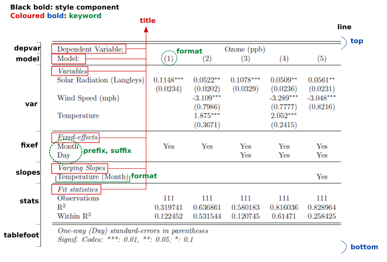

The argument `style.tex` only accepts outputs from the function `style.tex`. That function is documented and describes the different components that can be found in the previous illustration.

The function `style.tex` has two starting points (in the argument `main`), either the style of the first table displayed, or a much more compact style named “aer”. Let’s show the same table with the aer style, without stars beside the coefficients, and different fit statistics:

```r
etable(est, est_slopes, style.tex = style.tex("aer"),
       signif.code = NA, fitstat = ~ r2 + n, tex = TRUE)
```

Which yields the following table:

[figure not shown]

### Postprocessing with `postprocess.tex`

When `tex = TRUE`, `etable` returns a character vector. It is possible to modify it at will with the argument `postprocess.tex`. When a postprocessing function is detected, two additional tags are added to the character vector identifying the start and end of the table (`"%start:tab\\n"` and `"%end:tab\\n"`).

If we want to set the rule widths of the table, we could write the following function:

```r
set_rules = function(x, heavy, light){
  # x: the character vector returned by etable

  tex2add = ""
  if(!missing(heavy)){
    tex2add = paste0("\\setlength\\heavyrulewidth{", heavy, "}\n")
  }
  if(!missing(light)){
    tex2add = paste0(tex2add, "\\setlength\\lightrulewidth{", light, "}\n")
  }

  if(nchar(tex2add) > 0){
    x[x == "%start:tab\n"] = tex2add
  }

  x
}
```

Now we can summon that function from `etable`:

```r
etable(est, est_slopes, postprocess.tex = set_rules, heavy = "0.14em", tex = TRUE)
```

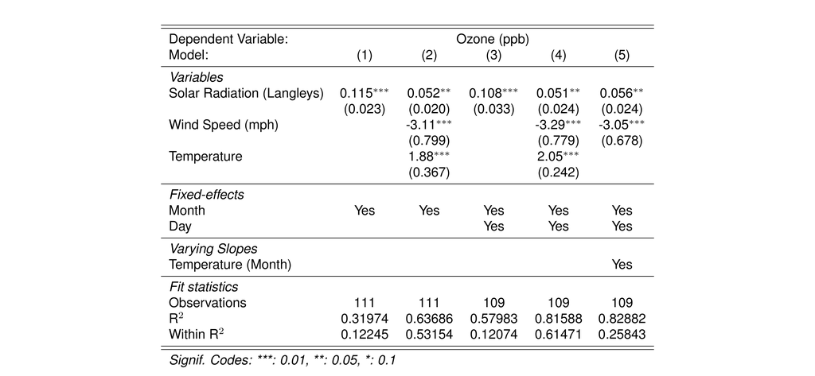

Of course it is even more convenient to set `set_rules` as the default postprocessing function, which provides a nice segue to the next section.

### Setting default values: LaTeX edition

To set the default values, like for the data.frame output, use `setFixest_etable`:

```r
setFixest_etable(style.tex = style.tex("aer", signif.code = NA), postprocess.tex = set_rules,
                 fitstat = ~ r2 + n)
```

Now we can access directly the arguments of the postprocessing function and the default style is the one of the second table:

```r
etable(est, heavy = "0.14em", tex = TRUE)
```

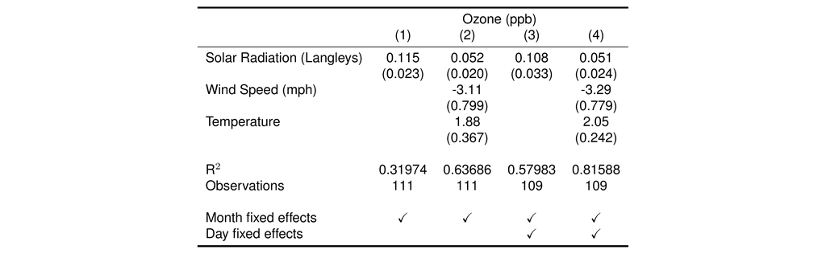

### Highlighting coefficients

Of course, LaTeX output gives you a lot more flexibility than printing to the console. A sharp example of this is the ability to highlight coefficients, which is especially useful for presentations. `etable` offers three ways to highlight coefficients:

- using a frame,
- coloring the cells,
- giving a custom style to the coefficients.

The first two can be accessed via the `highlight` argument. The last is implemented in the `coef.style` argument.

#### Frame

By default, the `highlight` argument superimposes a frame around the coefficients of interest. This is done thanks to some `tikz` magic found in [tex stack exchange](https://tex.stackexchange.com/questions/240542/adding-a-rectangular-box-with-tikz-to-table-beamer).

The syntax is `"options" = "coefficients location"`. The coefficient location can be expressed in several ways:

- the coefficient name: the full row is selected. Ex: `Petal.L` will select the `Petal.Length` row.
- the coefficient name followed by `@` and column ranges: in the coefficient row, only selects the given columns. Ex: `Petal.L@1,3-4` will select, in the row `Petal.Length`, the columns 1, 3 and 4.
- a vector of two coefficient cells: selects the full range from top-left to bottom right. Ex: `c("Petal.L@2", "Petal.W@3")` will select a range from the second column of `Petal.Length` to the third column of `Petal.Width`.

Let’s have an example illustrating the three ways to select the coefficients and some options. We switch to the `iris` dataset here since its `Species` factor gives us a nice split-sample layout. We also increase the row heights with `arraystretch` to facilitate the highlighting:

```r
nm = names(iris)
est_iris = feols(.[nm[1]] ~ .[nm[2:4]], iris, fsplit = ~Species)

etable(est_iris, arraystretch = 1.5, tex = TRUE,
       highlight = .("Sepal@1",
                     "cyan4, square" = "Petal.L@3-4",
                     "thick5, sep8, darkgreen!90, se" = "Petal.W"))
```

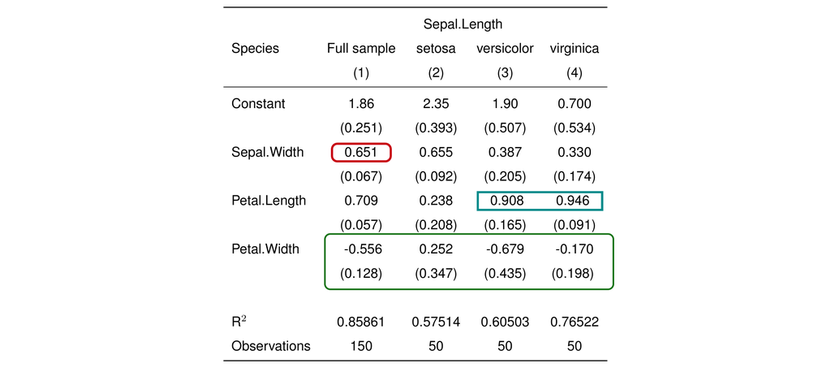

#### Row colors

Instead of highlighting coefficients with a frame, row color highlighting can be used. It is monitored with the same argument `highlight` and in fact you only have to add the option `rowcol` to make it work. Let’s replicate the previous example with row color:

```r
etable(est_iris, arraystretch = 1.5, tex = TRUE,
       highlight = .(rowcol = "Sepal@1",
                     "rowcol, cyan4!70" = "Petal.L@3-4",
                     "rowcol, darkgreen!40, se" = "Petal.W"))
```

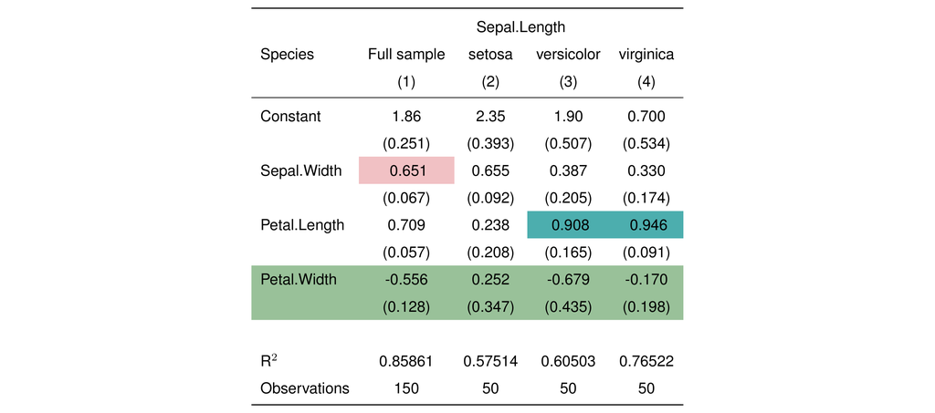

As opposed to the previous example, we only have increased the transparency of the colors with the `color!alpha` syntax.

Contrary to the frame, there are no options for the row coloring apart from the color itself and `se` to include the standard-errors.

#### Style

Using the same syntax as before to *select* the coefficients, it is possible to completely customize the coefficient cells. The syntax is `coef.style = .("style" = "coefficients location")` with style equal to LaTeX code containing the tag `:coef:` which will be replaced with the coefficient value. Alternatively, using the tag `:coef_se:` will apply the style both to the coefficient and the standard-error.

Here is the replication of the previous example with another highlighting:

```r
etable(est_iris, tex = TRUE,
       coef.style = .(":coef:$\\bigstar$" = "Sepal@1",
                      "**:coef:**" = "Petal.L@3-4",
                      "\\color{BrickRed} :coef_se:" = "Petal.W"))
```

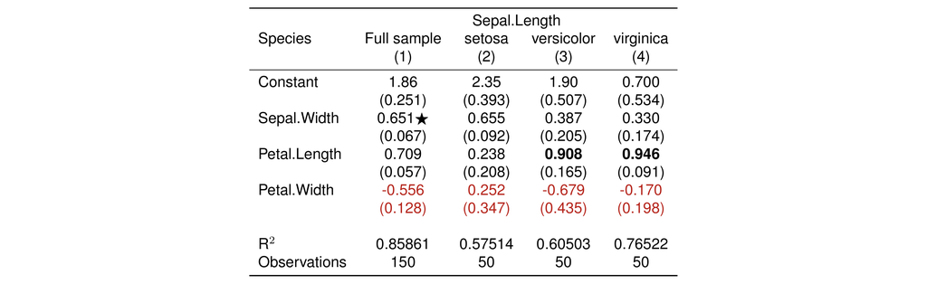

### LaTeX extras

While `style.tex`, `postprocess.tex`, `highlight` and co. can get you pretty far, it’s possible to customize to your `etable` output even further with the help of some third-party LaTeX packages. Note that you’ll have to install these these third-party packages yourself, but the `etable` code will execute regardless. Let’s see some examples.

#### threeparttable

The `threeparttable` LaTeX package lets you attach notes that automatically match the table width. You can enable it via `style.tex()`, and access notes from the global dictionary to avoid repetitions:

```r
# First define notes in the dictionary
setFixest_dict(c(note1 = paste0("*Notes*: This is a note that illustrates how to access notes ",
                                "from the dictionary."),
                 source = "*Sources*: Somewhere from the net."))

etable(est,
       style.tex = style.tex("aer", tpt = TRUE, notes.tpt.intro = "\\footnotesize"),
       notes = c("note1", "source"), tex = TRUE)
```

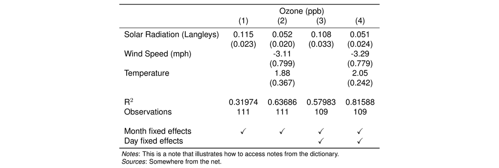

The table notes are adjusted to the table width thanks to `threeparttable` and the notes are accessed directly with their keys. The argument `notes.tpt.intro` inserts LaTeX code right before the first `\\item` of threeparttable: in this case, it sets the font to `footnotesize`.

In general, it is advised to set the value of `tpt` and the `notes.tpt.intro` globally. Then if one wants to change the value of `notes.tpt.intro`, instead of typing `style.tex = style.tex(notes.tpt.intro = "stuff")`, the first element of `notes` will replace `notes.tpt.intro` if it starts with an `"@"`:

```r
# Setting up tpt globally
my_style = style.tex(tpt = TRUE,
                     notes.tpt.intro = "\\footnotesize")
setFixest_etable(style.tex = my_style)

# Below is identical to:
#  etable(est,
#         style.tex = style.tex(notes.tpt.intro = "\\Large"),
#         notes = "These notes are large.")
etable(est, notes = c("@\\Large", "These notes are large."), tex = TRUE)
```

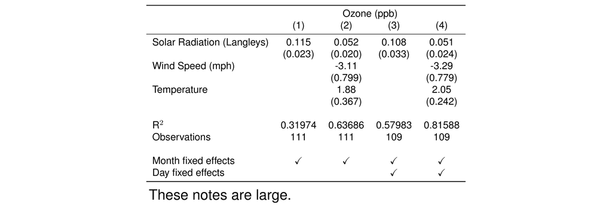

#### adjustbox

The `adjustbox` LaTeX package can resize a table to fit a target width—especially useful for wide tables that would otherwise overflow.

By default if `adjustbox = TRUE`, the table is nested in an `adjustbox` environment with the options `width = 1\\textwidth, center`. This argument can be equal to a number, in which case it will be treated as the desired text width. Otherwise it accepts any character string.

Let’s have an example with a large table that would otherwise overflow:

```r
est_many = feols(Ozone ~ mvsw(Solar.R, Wind, Temp), airquality)
etable(est_many, adjustbox = 1.1, tex = TRUE)
```

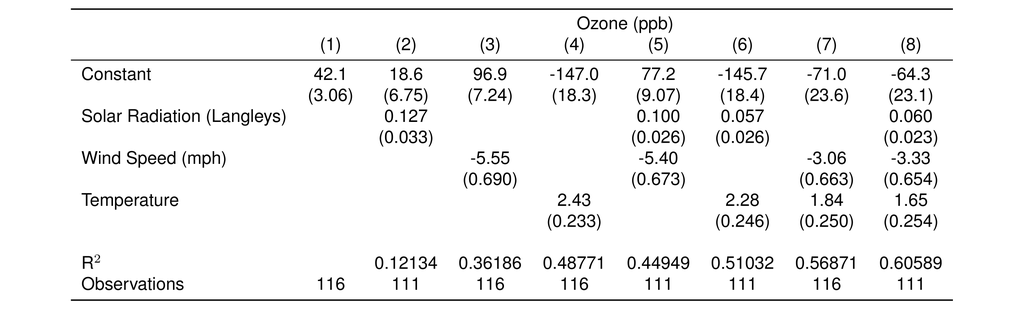

#### makecell

`fixest` supports markdown markup (`*`, `**`, `***`) for italics, bold, and bold-italics in most user-added text. It also supports the `makecell` LaTeX package for multi-line cells: simply include `"\n"` in your text. Here’s an example:

```r
# Reset defaults from previous sections
setFixest_etable(reset = TRUE)
```

```r
etable(est, headers = .("\n\n Short header" = 2, "*Very* \n **long** \n ***header***" = 2),
       tex = TRUE)
```

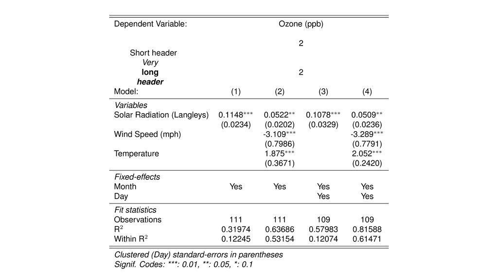

## Exporting tables to other formats

The primary output targets for `etable` are regular R data frames and LaTeX. This still leaves a variety of other formats off the table, including `.html`, `.docx` and `.typ`. While we don’t offer “native” support for these formats—and users may consider alternative software if that suits their workflow—we do at least provide a workaround that covers most other cases. Specifically, we can **export `etable` objects as PNGs**, which then allows for easy inclusion in HTML, MS Word documents, etc. We explain how this works below, but please note that it requires the following software to be installed first:

- `pdflatex` (shipped in most LaTeX distributions) **or** the R package [`tinytex`](https://CRAN.R-project.org/package=tinytex),
- [imagemagick](https://imagemagick.org/) and [ghostscript](https://www.ghostscript.com/), **or** the R package [`pdftools`](https://CRAN.R-project.org/package=pdftools/index.html).

### Exporting tables as PNGs

(Our thanks to Avishay-Rizi for the initial suggestion that led to this feature.)

The workaround here can be summarized as `etable -> LaTeX -> PDF -> PNG`. First, we take our `etable` call and compile a standalone LaTeX document (containing only the table) to PDF. Then, we call `imagemagick` under the hood to convert the PDF into a PNG file.

While this workflow might seem a bit convoluted, we do our best to automate the process so that everything “just works” from the end user’s perspective. In particular, we cover the most common use cases via convenience arguments for Quarto and Rmarkdown output (`markdown`) and integrated IDE viewer (`view`).

### Quarto and Rmarkdown: argument `markdown`

This option works only within `Quarto` and `Rmarkdown` documents and is ignored otherwise. If `markdown = TRUE` the output becomes always a LaTeX table, even when `tex = FALSE` (default). The output within the rendered document is contingent on the type of target file. If the document is being rendered to PDF, then a regular LaTeX table is returned. However, if the document is *not* being rendered to PDF (especially if it is an HTML file), then:

1. the PNG of the table is generated and saved in `images/etable/`, so that successive calls don’t need to re-generate the PNGs (i.e. this is caching),
2. the generated image is inserted in the document in an `<img>` tag,
3. that `<img>` tag is inserted in a `<div>` container of class `etable`.

This ensures that the tables are the same whether the output is a PDF or an HTML document. Since the table is embedded in a `<div>` container, you can add custom CSS to further customize how it looks (see the CSS section below).

**Fun fact:** all of the rendered tables from the postprocessing section onward in this article were generated using `markdown = TRUE`!

#### CSS for custom HTML output

When using `markdown = TRUE`, the image of the table is embedded in a `<div>` container whose default class is `etable`. You can set the class of that `<div>` manually with the argument `div.class` and apply custom CSS styling. You can add this as a custom CSS entry to your Quarto/Rmarkdown document for exporting to HTML, or bundle it as part of a theme. An example of the latter can be found in the [clean theme](https://grantmcdermott.com/quarto-revealjs-clean-demo/template.html#/regression-tables) for Quarto Reveal.js format.

#### Monitoring the look of the tables: the argument page.width

As mentioned, to generate a PNG image, a LaTex table is first embedded in a standalone LaTeX document, then the document is compiled to generate a PDF, and the PDF is converted to PNG. The default LaTex document has no page size and no margin, meaning that whatever the width of the table (be it two or twenty columns), it will always take 100% of the width of the PDF.

While this property is fine when displaying on the viewer, it makes the tables look odd and inconsistent in an HTML document. The `page.width` argument sets the width and side margins of the page in which the table will be inserted. The goal is to mimic the placement of the table in a *real* PDF document (i.e. in your article). For instance, `page.width = "a4"` will set an A4 page width and 2cm side margins on both sides. This argument can be customized at will: e.g. `8.5in, 1.1in` will lead to a page width of 8.5 inches with 1.1 inch side margins (the only constraint is that the unit of the width should be the same as the unit of the margin).

When `page.width` is set up, all tables in an HTML document will be consistent: the font will be the same across tables. On top of that, it also enables a couple of specific features. First, if the table is too narrow, you can use a *tabularx* table (with the argument `tabular`) and the table will be as large as the “text” width. Second, if the table overflows, you can adjust it with the argument `adjustbox` to make it fit the text width.

### RStudio and Positron (VS Code): argument `view`

The most popular R IDEs like RStudio and Positron (VS Code) come with their own dedicated viewer panels. If you would like to display the results of a regression table in one of these viewers, simply use the `etable(..., view = TRUE)` argument. This will invoke the PNG trick that we described above and display the resulting table snapshot in your IDE’s viewer.

Note that it can be useful to cache the PNG outputs to avoid the compilation run-time; at least if you plan on displaying the same tables multiple times in a row. Caching can be enabled with `setFixest_etable(view.cache = TRUE)`. The images are then saved in a temporary directory that the algorithm tries to find even across sessions (i.e., it should enable long-term caching).

## Custom fit statistics

It is often useful to include in a table some fit statistics that are not standard, or simply that may not be included in `fixest` built-in fit statistics. While it is possible to include any extra line in the table with the argument `extralines`, this is rather cumbersome and possibly error-prone if this task has to be repeated.

To avoid that kind of issue, `fixest` allows the user to register custom fit statistics. Once they are registered, they can be seamlessly called via the `fitstat` argument in `etable`.

Let’s continue with the previous example using the `airquality` data set, and now let’s display different p-values of statistical significance for the variable `Solar.R`. These p-values will vary depending on how we compute the VCOV matrix.

Here is an example that will shortly be explained:

```r
# Reset defaults from previous sections
setFixest_etable(reset = TRUE)
setFixest_dict(c(Ozone = "Ozone (ppb)", Solar.R = "Solar Radiation (Langleys)",
                 Wind = "Wind Speed (mph)", Temp = "Temperature"))

fitstat_register(type = "p_s", alias = "pvalue (standard)",
                 fun = function(x) pvalue(x, vcov = "iid")["Solar.R"])

fitstat_register(type = "p_h", alias = "pvalue (Heterosk.)",
                 fun = function(x) pvalue(x, vcov = "hetero")["Solar.R"])

fitstat_register(type = "p_day", alias = "pvalue (Day)",
                 fun = function(x) pvalue(x, vcov = ~Day)["Solar.R"])

fitstat_register(type = "p_month", alias = "pvalue (Month)",
                 fun = function(x) pvalue(x, vcov = ~Month)["Solar.R"])

# Now we display the results with the new fit statistics
etable(est, fitstat = ~ . + p_s + p_h + p_day + p_month)
```

```
#>                                         est.1              est.2             est.3
#> Dependent Var.:                   Ozone (ppb)        Ozone (ppb)       Ozone (ppb)
#>
#> Solar Radiation (Langleys) 0.1148*** (0.0234)   0.0522* (0.0202) 0.1078** (0.0329)
#> Wind Speed (mph)                              -3.109*** (0.7986)
#> Temperature                                    1.875*** (0.3671)
#> Fixed-Effects:             ------------------ ------------------ -----------------
#> Month                                     Yes                Yes               Yes
#> Day                                        No                 No               Yes
#> __________________________ __________________ __________________ _________________
#> S.E.: Clustered                       by: Day            by: Day           by: Day
#> Observations                              111                111               109
#> R2                                    0.31974            0.63686           0.57983
#> Within R2                             0.12245            0.53154           0.12074
#> pvalue (standard)                     0.00022            0.02957           0.00196
#> pvalue (Heterosk.)                    6.64e-6            0.02268           0.00093
#> pvalue (Day)                             3e-5            0.01468           0.00282
#> pvalue (Month)                        0.06066            0.26992           0.02600
#>
#>                                         est.4
#> Dependent Var.:                   Ozone (ppb)
#>
#> Solar Radiation (Langleys)   0.0509* (0.0236)
#> Wind Speed (mph)           -3.289*** (0.7791)
#> Temperature                 2.052*** (0.2420)
#> Fixed-Effects:             ------------------
#> Month                                     Yes
#> Day                                       Yes
#> __________________________ __________________
#> S.E.: Clustered                       by: Day
#> Observations                              109
#> R2                                    0.81588
#> Within R2                             0.61471
#> pvalue (standard)                     0.03720
#> pvalue (Heterosk.)                    0.02679
#> pvalue (Day)                          0.03973
#> pvalue (Month)                        0.29584
#> ---
#> Signif. codes: 0 '***' 0.001 '**' 0.01 '*' 0.05 '.' 0.1 ' ' 1
```

The function `fitstat_register` is a tool to add fit statistics in the `fitstat` engine. The first argument, `type`, is the code name by which the statistic is to be summoned. The argument `alias` provides the row name of the statistics: how it should look in the table. Finally in the `fun` argument is the function computing the statistic. That function must apply to a `fixest` estimation and must also return a single value.

Once these statistics are registered, they can seamlessly be summoned with the argument `fitstat` and will appear in the order the user provides. Note that the dot in `fitstat = ~ . + p_s + etc` represents the default statistics to be displayed and need not be there.

## Other tabling software

Thanks to community contributors, `fixest` objects are supported by both [broom](https://broom.tidymodels.org/index.html) and [parameters](https://easystats.github.io/parameters/). These two packages provide the common building blocks for extracting relevant information from a huge variety of R model classes, which in turn opens the possibility for easy integration with generic tabling software.

Two of the most popular tabling packages in R are modelsummary and [gtsummary](https://www.danieldsjoberg.com/gtsummary/), which are both excellent and happily recommended. You may well prefer to use either of these if you are working with additional model classes beyond `fixest` objects, or you require the seamless integration that they provide for different Quarto and Rmarkdown output formats (including HTML, MS Word, and Typst). The downside to using these external packages is that they are, necessarily, less tightly integrated with `fixest` objects and may require more code to achieve the same results.

Regardless of your preferences, here are some tips for working with `fixest` objects and alternative tabling software.

- Multiple estimations, like the object `est` in the previous examples, are a bit special and `broom` methods can’t apply directly. To export them, you first need to coerce the results into a list: by simply using `as.list(est)`.
- By default, in `fixest` the estimations are separated from the calculation of the VCOV matrices. That’s not a problem when using `etable` since, after providing the argument `vcov` or `cluster`, all VCOVs are calculated at once. Using other tools for exportation requires a call to `summary` for each model to compute the appropriate standard-errors. But this process can also be automatized. The function `.l()` can be used to coerce several `fixest` objects to which `summary` can then be applied, for example:

  ```r
  summary(.l(est, est_slopes), cluster = ~ Month)
  ```

  The previous code returns a list of the five estimations for which the standard-errors are all clustered at the Month level, and can then be exported with external software.
[^1]: Specifically, it returns a `data.frame` as long as the `tex` or `file` arguments are missing.